# False discovery rate control with empirical null distributions

## Presentation by Charles Zheng

Reference: A Schwartzmann, R Dougherty, *et al*. `Empirical null and false discovery rate analysis in neuroimaging'. *NeuroImage* 2008

# Are you using the right null distribution??!

[figure not shown]

Dashed: theoretical null (N(0,1)). Solid: empirical null

[figure not shown]

Dashed: theoretical null \(\chi^2\). Solid: empirical null

### Estimating the 'null'

- Assume that the actual null distribution is a shifted or scaled version of the theoretical null
- Assume that the test statistics in most (90% + ) of the voxels are drawn from the null
- Estimate the null distribution from the 'bulk' of the empirical distribution

## Example 1

- Simulate 10,000 voxels, voxels[0:100] are non-null and voxels[100:10000] are null
- Non-null voxels are drawn from \(N(-.3, 5)\)
- Null voxels are drawn from \(N(0.2, 1.2)\)

```python
import numpy as np
import numpy.random as npr
import matplotlib.pyplot as plt
voxels = np.zeros(10000)                                # allocate the initial vector
voxels[0:100] = npr.normal(-0.3, np.sqrt(5), 100)       # sample the non-null voxels
voxels[100:10000] = npr.normal(0.2, np.sqrt(1.2), 9900) # sample the null voxels
```

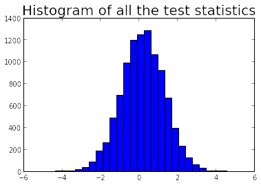

```python
plt.hist(voxels, bins = 30)
plt.title('Histogram of all the test statistics', fontsize = 20)
plt.show()
```

## Estimating the null

- Use only the data from the 'bulk' (the 1st to 3rd quantiles)

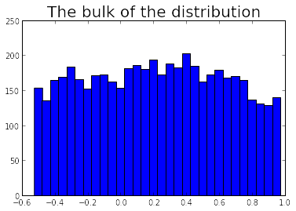

```python
sorted_voxels = sorted(voxels)
bulk_voxels = sorted_voxels[2500:7500]
plt.hist(bulk_voxels, bins = 30)
plt.title('The bulk of the distribution', fontsize = 20)
plt.show()
```

- We assume that the bulk contains mostly samples from the null distribution
- Since this is a simulation, we can actually check that assumption

```python
n_null = len([v for v in voxels[:100] if v >= min(bulk_voxels) and v <= max(bulk_voxels)])
n_alt = len([v for v in voxels[100:] if v >= min(bulk_voxels) and v <= max(bulk_voxels)])
print('Number of null voxels in bulk: ' + str(n_null))
print('Number of non-null voxels in bulk: ' + str(n_alt))
```

[output not shown]

## Fitting the null distribution

The density is given by

\[ f_0(z) = \frac{1}{\sqrt{2\pi \sigma^2}} \exp\left(\frac{-(z-\mu)^2}{2\sigma^2}\right) \]